# Mechanical Design Process

#### Henry Sigel

**Initial Design Constraints:**  
The project’s mechanical design requires innovative approaches to mixing the air within the chamber while ensuring that all components remain readily available. This means incorporating parts from accessible sources such as hardware stores and, where necessary, using 3D-printed elements for custom-fit solutions. Another critical constraint is safeguarding the electronics from water exposure to maintain both device longevity and measurement accuracy. Throughout these efforts, the chamber’s integrity must be preserved to sustain a constant internal volume during measurements.

**Brainstorming Ideas for Clearing the Chamber:**  
Several strategies are under consideration for effectively mixing and clearing the air inside the chamber. The simplest current solution involves a fan, which is both compact and familiar. Alternatives include using compressed air, harnessing natural wind, or installing a hatch door—on top or to the side—that can be securely sealed to keep the chamber airtight. Another intriguing concept is an accordion-style wall capable of lifting and sealing the chamber from water, providing both mixing functionality and protection.

**Additional Design Considerations:**  
Beyond air mixing, the design must integrate adequate supports, whether placed internally or externally, to maintain structural stability. The electronics need to remain safely above the waterline, which may necessitate placing them in a Stevenson box sheltered from moisture. A fan beneath the Stevenson box could enhance internal airflow, and the idea of a movable flap is also under review to optimize mixing. Each of these considerations will inform the final design, balancing practicality, resilience, and ease of maintenance. Initial Sketch

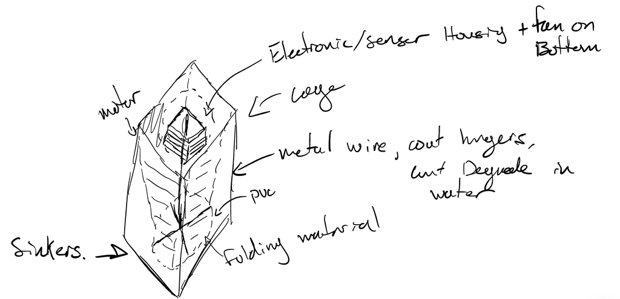

Initial CAD Models

[video not shown]

Secondary CAD Models

Variations

- Exterior supports with a cylidrical chamber

[video not shown]

- Interior supports with a cylidrical chamber

[video not shown]

- Interior supports with floatation supports coming from the top with a cylindrial chamber

[video not shown]

- Interior supports with floatation supports coming from the top with a square chamber, square chamber can be adapted for any other model

[video not shown]

On November 20th, following our consultation with the scientists, we revisited the design specifications for our third round of models. The key objective is to ensure that the units are easily transportable, since multiple devices may need to be carried through forested areas. To achieve this, size has become a critical factor. We need to carefully select solar panel dimensions to meet the required power capacity, as well as determine the minimum chamber height to protect our electronics. In addition, we will evaluate our motor options and the materials used for the chamber sides. This iteration will also incorporate a fan mounted beneath the Stevenson box. Here, questions arise about the fan’s exposure to moisture, whether a rod will pass through it, and how the fan’s size will influence overall design complexity.

We must find the right balance between too small and too large a volume, ensuring the design is robust yet manageable. Another key choice involves how best to mix the air before taking measurements—whether to employ a fan for on-demand circulation or a solenoid for more controlled airflow. Securing the electronics is also a priority, and the team is considering a clamp to fasten components to the top plate. Finally, to maintain an airtight environment, the bottom portion of the structure should be submerged 1–2 centimeters into the water, preserving the internal conditions required for accurate data collection.

CAD Model with some changes implemented

[video not shown]

Material Testing and Prototyping:

Elasticity and Durability: Conduct small-scale tests on each candidate material—rubber sheeting, plastic-coated canvas, and thin plastic films—to assess elasticity, tear resistance, and long-term durability under repeated folding.

Water Resistance Trials: Spray test builds to confirm their ability to repel water and maintain an airtight seal once incorporated into the accordion structure.

Adhesion and Bonding: Experiment with different bonding methods (e.g., adhesives, sewing, heat sealing) to determine how well seams hold under stress and exposure to moisture. The seam along the acordian material will be weaker, test how it holds up to folds.

Weighting Options: Test different systems for wieght. Check to make sure the sensor will flaot

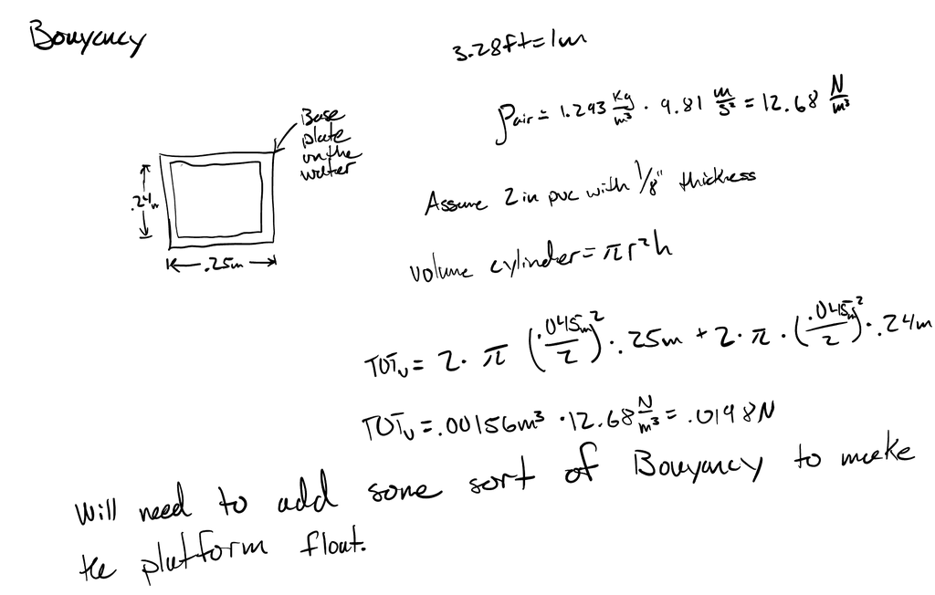

Bouyancy Calculation for just PVC pipe

FrameIntegration: How are we going to connect the acordian structure to the top of structure.

Temperature Range: Check material performance under different temperatures to ensure the accordion walls maintain flexibility and seal integrity.

When building the methane sensor, choosing the right materials was crucial. I went to Home Depot to source the majority of our parts, as we wanted the sensor to be easily replicated. Since we were building a prototype, the unit is not cost-optimized, and there will be room to make it more economical later.

I chose 1" PVC pipe because it seemed like a reasonable size for the structure I wanted to build. I wasn’t concerned about buoyancy because I knew I’d have to add foam regardless of the volume of air inside the pipe. For the foam, the obvious choice was a pool noodle, but since I wanted to source everything from one store, I found a suitable replacement. This alternative also had the benefit of coming with a known inner radius, as it was designed for pipe insulation. Home Depot had a pack of four foam insulating covers—I only needed two—which will work perfectly.

For the inner membrane, my original plan was to use roofing membrane. Unfortunately, our Home Depot is one of the smaller locations, meaning they carry less stock—including that item. This was disappointing, and I assumed I’d have to order it online. As I was checking out, I mentioned this to the attendant, and she gave me a great recommendation: a perfectly malleable sheet of rubber, sold in just the right quantity. I ended up getting a 5' x 6', 40 mil thick shower pan liner. Since I had a square top but wanted a circular membrane, I needed to find a pattern to cut it out. I followed a duct pattern, which worked quite well. While a square opening would’ve been easier to produce, the circular shape provides more even weight distribution with the insert, and it folds more naturally without putting stress on the joints.

The only structural components left were the roof and insert. For this, I knew I wanted to use plastic—something I could cut easily with just an X-Acto knife, but still strong enough to hold its shape and support the weight of the rubber. I chose a large LED lighting panel, like the kind you might see in offices or schools. Its rough texture is perfect for bonding with caulk, which I used to seal the unit, both on the top and at the seam.

The size and proportions of the chamber can be easily adjusted during the production process. For this prototype, I used 14" pieces of PVC for the X and Y dimensions, and 10" for the Z. These measurements are completely arbitrary and should be changed to meet user specifications. One important consideration is maintaining a high water surface area to volume ratio. This allows the sensor to better detect slower rates of methane emissions.

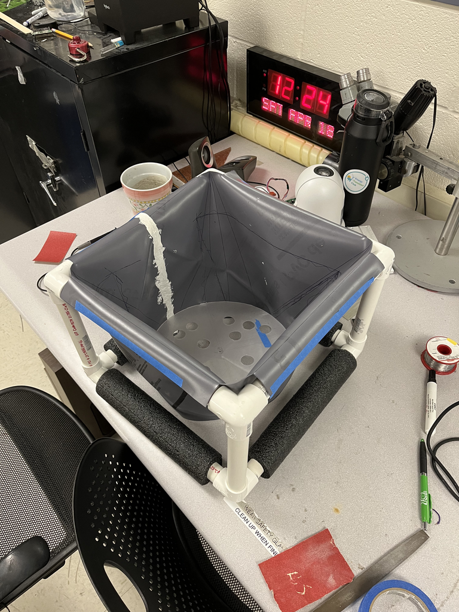

[figure not shown]

In order to flush the volume inside, we are using a stepper motor—a NEMA 17—driven by an Adafruit stepper motor driver. I wrote a simple script to run the motor, which reverses at the push of a button. Because we want to flush the entire volume, I’ll implement a script where the motor waits five minutes at the top to allow for a complete exchange. I plan to attach a threaded metal rod to the stepper motor, with a nut fixed to the plastic insert that is connected to the rubber material. This setup will convert the radial motion produced by the stepper motor into linear motion.

I had to order these parts, including a coupling to connect the motor to the threaded rod. This system ended up costing about as much as all the other physical components combined, but it could be made cheaper if you sourced a good kit for stepper motor linear motion. I’d recommend doing this when additional systems are created.